# Notebook technique de l’étude térritorial TP2

Timm Rogenmoser

12/8/2022

### Table des matières

- **1. Réglages de base et préparation des calculs ultérieurs**
- **2. Régression logistique multinomiale**
- **3. Analyse en composants principales (ACP)**
- **4. Clustering**

### 1. Réglages de base et préparation des calculs ultérieurs

#### 1.1 Chargement des packages nécessaires

Tout d’abord, le package *ggplot2* nécessaire pour les calculs sont chargé **dans le library** (le répertoire où les packages sont stockés):

```r
library(ggplot2)
```

```r
path = getwd()
setwd(path)
```

### 2. Régression logistique multinomiale

#### 2.1 Introcuction théorique

Le principe de la régression logistique multinomiale est d’expliquer ou de prédire une variable qui peut prendre J valeurs alternatives (les J modalités de la variable) en fonction de variables explicatives.

#### 2.2 Procédure de calcul

Charger package nnet; Nnet est une bibliothèque de réseaux neuronaux artificiels (Artificial Neural Network ANN). La raison pour laquelle cette librairie est utilisée dans la régression logistique est qu’elle peut être considérée comme un cas particulier simple de réseau neuronal, la fonction multinom permettant automatiquement de construire un réseau neuronal en interne.

```r
library(nnet)
```

Ensuite, on charge les données nécessaires (qui sont sauvgardé en fichier .csv) pour les calcules avec la fonction **read_csv()** et on donne un nom au fichier, ce qui va faciliter les calcules par la suite.

Cette fonction **read_csv()** permet d’ouvrir les données en fonction du chemin d’accès.

Données de la région Wynental(Canton de Argovie):

```r
d=
read.csv(file="../donnees/Etappe 1/donnees_wynental_tp2.csv", sep="\t")
```

Les variables suivantes se trouvent dans le fichier… également avec une explication de leurs abbréviations:

- *TYPE*: Typologie de la commune définie par l’Office fédéral de la topographie en 2012
- *SAU*: Proportion de la surface agricole utile (en hectar) par rapport à la surface totale de la commune (en hectar)
- *EPT1*: Proportion des emplois du secteur primaire par rapport au total des emplois dans la commune
- *SURFHAB*: Proportion de la surface des batiments d’habitat (ha) par rapport au total de la surface de la commune (ha)
- *RESSEC*: Proportion des résidents secondaires par rapport à tout les types des batiments dans la commune

Pour regarder de plus près la variable dépendante:

```r
table(d$typologie_ofs_court)
```

```
## < table of extent 0 >
```

Dans le chunk suivant je crée deux jeux de données dont j’aurai besoin plus tard pour la création du modèle. En effet, à partir du jeux de données initial, il est possible de créer, avec les fonctions suivantes, des données de calibrage (training data), ainsi qu’un jeu de données de test pour la validation. La première contient 90% (dtrain) des données et la seconde 10% (dtest).

Nous exécutons d’abord le modèle de régression sur le jeu de données (données d’entraînement= dtrain), puis nous l’appliquons au dtest pour évaluer son efficacité. Les deux jeux de données prennent les données au hasard dans le jeu de données de base. L’objectif est alors que le modèle fasse à chaque fois des prédictions sur des données différentes, ce qui rend plus facile l’évaluation de sa capacité de prédiction.

```r
idx = sample(nrow(d), size=0.9*nrow(d))
dtrain = d[idx,]
dtest = d[-idx,]
```

Il est maintenant possible de calculer la régression multinomiale à l’aide de la fonction multinom (l’utilité de multinom est expliqué plus en haut à l’installation du package “nnet”.

```r
regmlogit = multinom(TYPE ~ SAU + EPT1 + SURFHAB + RESSEC,
                     data=dtrain)
```

```r
summary(regmlogit)
```

```
## Call:
## multinom(formula = TYPE ~ SAU + EPT1 + SURFHAB + RESSEC, data = dtrain)
##
## Coefficients:
##        (Intercept)      SAU       EPT1   SURFHAB     RESSEC
## Rural    -6.492813 18.84963  -5.587524 -132.2424 163.268700
## Urbain  -30.425542 16.35522 -27.096591  135.9698   6.661133
##
## Std. Errors:
##        (Intercept)       SAU      EPT1  SURFHAB    RESSEC
## Rural     48.83403  44.93045  73.87329 232.0261  236.3305
## Urbain   242.13370 105.01452 478.57948 285.7914 2513.6058
##
## Residual Deviance: 0.4416835
## AIC: 20.44168
```

Nous avons en fait deux modèles différents, un pour chacune des catégories, sauf pour une catégorie. Cela est dû au fait que nous estimons des probabilités pour chaque catégorie et que la somme des probabilités doit être égale à 1. Ainsi, si nous avons calculé la probabilité pour deux catégories, nous pouvons calculer la probabilité pour la dernière catégorie par un simple calcul.

Pour l’évaluation, nous pouvons faire un tableau comparatif simple entre les catégories prédites et les catégories effectives pour le jeu de données de calibrage et celui de test:

```r
table(predict(regmlogit, newdata=dtrain),
      dtrain$TYPE)
```

```
##
##          Agglo Rural Urbain
##   Agglo      2     0      0
##   Rural      0    16      0
##   Urbain     0     0      4
```

```r
table(predict(regmlogit, newdata=dtest),
      dtest$TYPE)
```

```
##
##          Agglo Rural
##   Agglo      1     0
##   Rural      0     2
##   Urbain     0     0
```

Et nous pouvons calculer la proportion de régions classées correctement, pour les deux jeux de données:

```r
accuracy_train = sum(predict(regmlogit, newdata=dtrain) == dtrain$TYPE) / nrow(dtrain)
accuracy_test = sum(predict(regmlogit, newdata=dtest) == dtest$TYPE) / nrow(dtest)
```

```r
accuracy_train
```

```
## [1] 1
```

```r
accuracy_test
```

```
## [1] 1
```

```r
mean(accuracy_train_d)
```

```
## [1] 0.9645455
```

```r
mean(accuracy_test_d)
```

```
## [1] 0.89
```

```r
var(accuracy_train_d)
```

```
## [1] 0.0003581267
```

```r
var(accuracy_test_d)
```

```
## [1] 0.03154882
```

```r
 table(predict(regmlogit, newdata=dtrain),
      dtrain$TYPE)
```

```
##
##          Agglo Rural Urbain
##   Agglo      1     0      0
##   Rural      1    17      0
##   Urbain     0     0      3
```

```r
 table(predict(regmlogit, newdata=dtest),
      dtest$TYPE)
```

```
##
##          Agglo Rural Urbain
##   Agglo      1     0      0
##   Rural      0     1      0
##   Urbain     0     0      1
```

```r
table(predict(donnees_regmlogit, newdata=d),
      d$TYPE)
```

```
##
##          Agglo Rural Urbain
##   Agglo      2     0      0
##   Rural      1    18      0
##   Urbain     0     0      4
```

Création d’un vecteur avec prédiction de modèle

```r
vector_prediction = predict(regmlogit,newdata = d)
```

La fonction **write.table** permet d’exporter le vecteur sous forme de colonnes pour ensuite vérifier les prédictions dans excel et afficher les erreurs. Avec **col.names** il est possible d’ajouter un titre au colonne et avec **sep**, les values peuvent etre separé avec des “;”.

```r
write.table(vector_prediction,"colonne_prediction.csv",sep = ";", col.names = "Prediction")
```

### 3. Analyse en composants principales (ACP)

#### Introduction théorique

L’analyse en composantes principales (ACP) est un outil de compression et de synthèse de l’information, très utile lorsqu’il faut traiter et interpréter une grande somme de données quantitatives (Openeditions, 2018). **L’objectif de l’ACP est de revenir à un espace de dimension réduite en déformant le moins possible la réalité**. Il s’agit donc d’obtenir un **résumé le plus pertinent possible** des données initiales (Wikistat, 2021).

#### Préparation du jeu de données

Premièrement, on charge les données nécessaires (qui sont sauvgardé en fichier .csv) pour les calcules avec la fonction **read_csv()** et on donne un nom au fichier, ce qui va faciliter les calcules par la suite.

Cette fonction **read_csv()** permet d’ouvrir les données en fonction du chemin d’accès.

Données de la région Wynental(Canton de Argovie):

```r
d2 = read.csv(file="../donnees/Etappe 2/acp_donnees_5.csv", sep="\t")
```

Après avoir importer les données, on peut afficher les premières lignes du tableau pour des fins de vérification. Pour cela on utilise la fonction **head()** et on paranthèse on précise la nombre de lignes souhaitée dans l’affichage:

```r
head(d2, 3)
```

```
##         Communes       SAU      EPT1   SURFHAB RESSEC    SURFIND      RETR
## 1 Beinwil am See 0.5000000 0.0279412 0.2460733 0.1147 0.02094241 0.1875000
## 2        Birrwil 0.6246334 0.1328671 0.1085044 0.1730 0.00879765 0.2035124
## 3      Burg (AG) 0.2872340 0.2304348 0.2978723 0.1302 0.02127660 0.1349446
##          ADO IP_270920 IP_250916 IP_291120 IP_130222
## 1 0.11379076      0.45      0.37      0.47      0.23
## 2 0.07334711      0.47      0.37      0.37      0.17
## 3 0.09667674      0.57      0.44      0.43      0.34
```

Pour vérifier le nombre de colonnes on utilise la fonction **ncol()**

```r
ncol(d2)
```

```
## [1] 12
```

Nous pouvons maintenant extraire toutes les variables numériques que nous utiliserons dans l’ACP (colonnes 2 à 6). Nous ne tenons pas compte des noms des communes (colonne 1). N.B : D’autres colonnes (ADO et les différentes initiatives populaires (IP_XY)) ont également été supprimées pour le calcul de l’ACP. En effet, l’inclusion de ces colonnes rendait l’ACP moins qualitative (c’est-à-dire que les variables n’expliquaient que 39% de la première dimension). Grâce à l’adaptation de l’ACP et à l’inclusion des colonnes 2 à 6, la première dimension est désormais expliquée à plus de 50% et est donc acceptable.

```r
d2_acp = d2[,2:6]
```

Le nouveau tableau réduit se présente maintenant comme suit et peut être affiché avec la fonction **head()** :

```r
head(d2_acp, 3)
```

```
##         SAU      EPT1   SURFHAB RESSEC    SURFIND
## 1 0.5000000 0.0279412 0.2460733 0.1147 0.02094241
## 2 0.6246334 0.1328671 0.1085044 0.1730 0.00879765
## 3 0.2872340 0.2304348 0.2978723 0.1302 0.02127660
```

#### Explorer les données

L’exploration des données permet de mieux connaitre les données. En particulier, les corrélations entre les différentes variables sont examinées ici. La raison en est que l’ACP est principalement utilisée pour réduire les dimensions (une dimension est une variable) –> c’est-à-dire pour limiter le nombre de variables afin que seules les deux ou trois premières composantes soient visibles. **Avoir un nombre limité de composantes aidera plus tard à l’interprétation, qui est listée dans l’autre notebook**. Dans ce sens, un ensemble de données se prête bien à une réduction de la dimensionnalité lorsque plusieurs variables sont corrélées entre elles, c’est-à-dire qu’elles représentent la même information. Nous allons donc extraire la matrice de corrélation et voir si plusieurs variables sont corrélées à plus de 0,5. Le fait que les corrélations soient plutôt élevées ou non dépend principalement du jeu de données. La fonction suivante permet d’afficher la matrice de corrélation (la première ligne n’est là que pour s’assurer que la matrice entière est affichée) :

```r
options(repr.matrix.max.rows=600, repr.matrix.max.cols=200)
cor(d2_acp)
```

```
##                 SAU        EPT1     SURFHAB      RESSEC     SURFIND
## SAU      1.00000000  0.51881922 -0.47230093  0.04419509 -0.29678652
## EPT1     0.51881922  1.00000000 -0.44920314 -0.09275519 -0.61583162
## SURFHAB -0.47230093 -0.44920314  1.00000000  0.09154476  0.69025085
## RESSEC   0.04419509 -0.09275519  0.09154476  1.00000000  0.09106039
## SURFIND -0.29678652 -0.61583162  0.69025085  0.09106039  1.00000000
```

En observant le tableau généré, on constate qu’il y a toute une série de corrélations avec des valeurs supérieures à 0,5. Cependant, ces valeurs sont également mélangées avec d’autres variables qui ne sont que faiblement corrélées avec les autres. Le calcul suivant permet donc d’afficher les valeurs maximales et minimales des corrélations par colonne en éliminant la corrélation 1.0 de la diagonale :

```r
cor_mat = cor(d2_acp)
cor_mat[cor_mat == 1.0] = 0
apply(cor_mat, 1, range)
```

```
##             SAU       EPT1    SURFHAB      RESSEC    SURFIND
## [1,] -0.4723009 -0.6158316 -0.4723009 -0.09275519 -0.6158316
## [2,]  0.5188192  0.5188192  0.6902508  0.09154476  0.6902508
```

#### Calcul de l’ACP

Il existe différentes fonctions dans R qui permettent de calculer une ACP. Selon les recommandations du Workbook du professeur Kaiser, la fonction PCA du package “FactoMineR” est utilisée dans cette recherche. Celle-ci peut être chargée avec la fonction **library()** :

```r
library(FactoMineR)
```

```r
# install.packages(c('FactoMineR'))
```

```r
# install.packages(c("factoextra", "ggpubr"))
```

Le package “Factoextra” est également chargé. La fonction **library()** est également utilisée à cet effet :

```r
library("factoextra")
```

Les fonctions suivantes permettent de dessiner le graphique PCA des variables. **N.B. : La fonction** ncp** permet de définir le nombre de dimensions que l’on souhaite conserver, soit 5. Dans ce cas, nous nous limitons à 5. Il est également important de noter qu’une ACP est très sensible aux valeurs des données, c’est pourquoi il est très important de standardiser les données… ceci est possible grâce à la fonction **scale.unit=TRUE** :

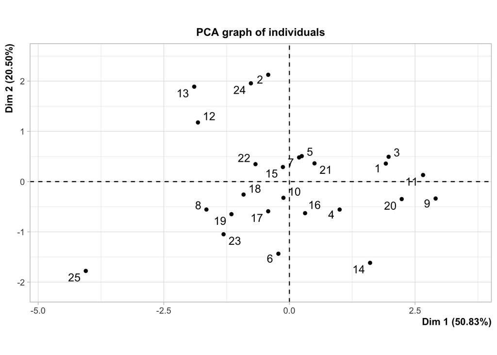

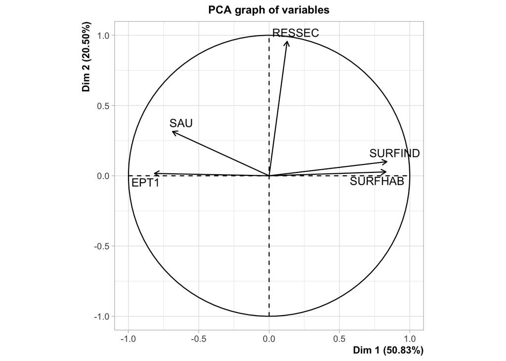

```r
d2_acp = d2[,2:6]
acp = PCA(d2_acp, scale.unit=TRUE, ncp=5, graph=TRUE)
```

La fonction **get_eig()** permet d’afficher un premier résultat de l’ACP :

```r
get_eig(acp)
```

```
##       eigenvalue variance.percent cumulative.variance.percent
## Dim.1  2.5414431        50.828862                    50.82886
## Dim.2  1.0251761        20.503521                    71.33238
## Dim.3  0.7062442        14.124883                    85.45727
## Dim.4  0.5323860        10.647719                    96.10499
## Dim.5  0.1947507         3.895014                   100.00000
```

Si nécessaire, on peut réduire les résultats à un nombre souhaité à l’aide d’une parenthèse d’angle : **N.B:** Les valeurs propres sont indiquées dans la colonne de gauche. La part de la variance expliquée montre l’importance de la composante (la part d’information saisie). La part cumulative de la variance expliquée est la somme de la variance expliquée de toutes les composantes qui sont plus importantes.

```r
get_eig(acp)[1:5,]
```

```
##       eigenvalue variance.percent cumulative.variance.percent
## Dim.1  2.5414431        50.828862                    50.82886
## Dim.2  1.0251761        20.503521                    71.33238
## Dim.3  0.7062442        14.124883                    85.45727
## Dim.4  0.5323860        10.647719                    96.10499
## Dim.5  0.1947507         3.895014                   100.00000
```

**N.B**: **Pour avoir une bonne ACP, il faut généralement viser une première composante qui explique au moins 50% de la variance, et les quatre premières composantes arrivent à 85% de variance expliquée.** –> Pour cette raison, certains indicateurs qui sont trop indépendants (qui ont une faible corrélation avec d’autres variables), ou qui sont mal repris par les composantes ont étaient enlevées (comme expliqué plus en haut dans cette notebook!).

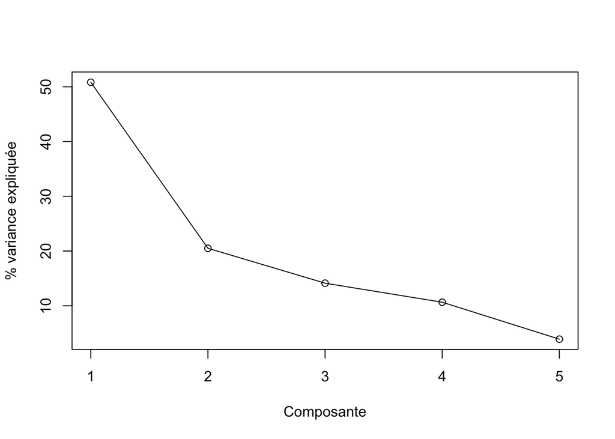

```r
plot(acp$eig[1:5,2], type="o", xlab="Composante", ylab="% variance expliquée")
```

Un représentation encore plus visuel peut etre fait avec le package factoextra:

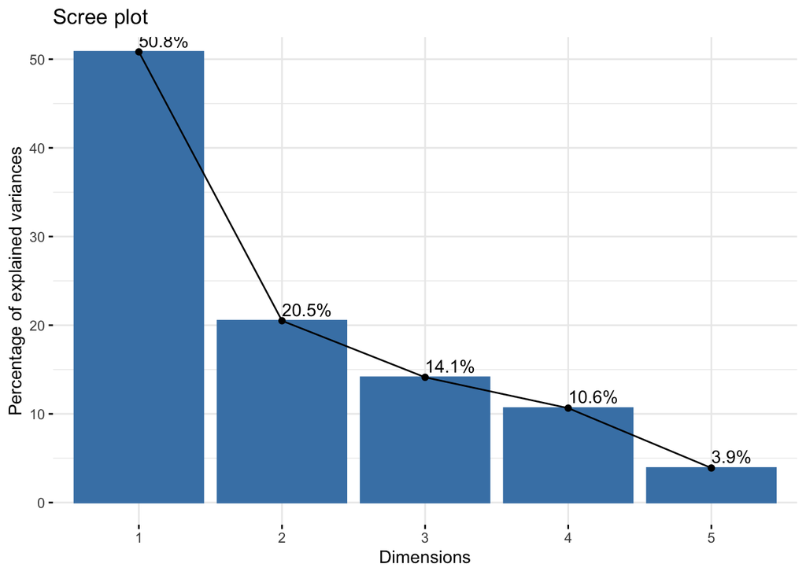

```r
fviz_screeplot(acp, addlabels = TRUE, ylim = c(0, 50))
```

#### Les socres factoriels

Les scores factoriels déterminent le lien entre les régions analysées et les composantes principales. Avec la fonction **plot.PCA()** ils est possible d’afficher un graphique des régions en fonction des composantes (ici les deux premières):

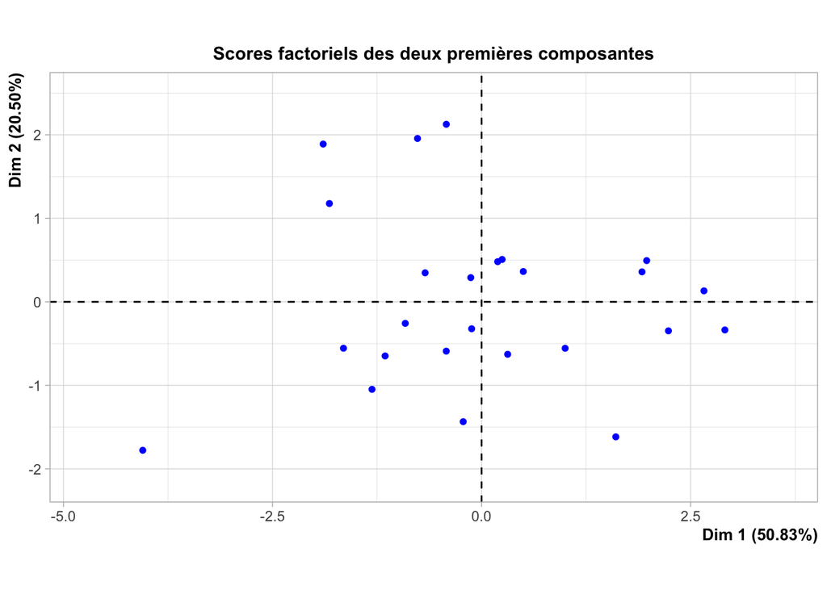

```r
plot.PCA(
    acp,
    axes=c(1,2),
    title="Scores factoriels des deux premières composantes",
    label="none",
    col.ind="blue"
)
```

Egalement il est possible d’afficher les scores factoriels avec la couleur qui indique la qualité de chaque région par rapport à la dimension:

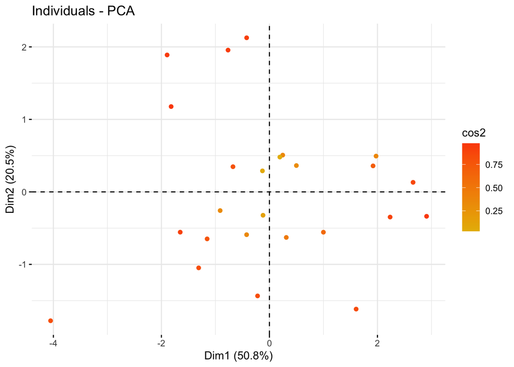

```r
fviz_pca_ind(
    acp,
    col.ind="cos2",
    gradient.cols=c("#E7B800", "#FC4E07"),
    geom="point"
)
```

Les scores factoriels en tant que tel peuvent être affichés avec la fonction suivante:

```r
acp$ind$coord
```

```
##         Dim.1      Dim.2        Dim.3       Dim.4       Dim.5
## 1   1.9184492  0.3588250  0.594136198  0.50616425 -0.98764520
## 2  -0.4219685  2.1257688 -0.495319157  0.02235467 -0.38732626
## 3   1.9741895  0.4937061  0.162864807  2.66309799 -0.14464136
## 4   0.9992578 -0.5562525 -0.465288087 -0.66492494  0.40405615
## 5   0.2458842  0.5074436  0.201738276 -0.72642854  0.01998150
## 6  -0.2197270 -1.4349635 -0.227418657 -0.26714294 -0.56080010
## 7   0.1926488  0.4805607  2.717107250 -0.89560798  0.40537570
## 8  -1.6518783 -0.5557457 -0.173656347  0.14995579 -0.52081697
## 9   2.9094416 -0.3367146  0.229714562  0.40077512  0.14353021
## 10 -0.1188989 -0.3224250 -0.613673447 -0.59120686 -0.18862093
## 11  2.6593708  0.1315891  1.001844380 -0.06495491  0.37309071
## 12 -1.8201644  1.1769515 -0.246037450 -0.21445794 -0.05699220
## 13 -1.8945232  1.8889425 -0.339167677  0.49006080  0.20815595
## 14  1.6051688 -1.6167916 -0.955434394  0.05762826 -0.25028443
## 15 -0.1294452  0.2898376  0.772674599 -0.61497716 -0.75272841
## 16  0.3118359 -0.6282826  0.006283796 -0.73801230 -0.10747962
## 17 -0.4225547 -0.5904358 -0.584288980 -0.57337156 -0.57707374
## 18 -0.9126482 -0.2578580 -1.073479677  0.63791577  0.56349977
## 19 -1.1536027 -0.6480733 -0.669836684  0.18505285  0.18911952
## 20  2.2343313 -0.3472391 -0.207228311 -0.13073716  0.78435205
## 21  0.4988048  0.3632558 -0.590520230 -0.46440679  0.53120279
## 22 -0.6750431  0.3473659  0.266531107 -0.28227462 -0.05282033
## 23 -1.3104176 -1.0478670 -0.626822081  0.03852955  0.46087505
## 24 -0.7664168  1.9559112 -0.466627048 -0.05505305  0.25091208
## 25 -4.0520937 -1.7775094  1.781903251  1.13202172  0.25307808
```

Pour exporter ces données on utilise la fonction **write.csv()** (comme à la première étappe)

```r
write.csv(acp$ind$coord, file="scores-factoriels2.csv")
```

Ceci permet un traitement des données dans des logiciels de cartographie tels que QGIS ou logiciels de graphisme comme Illustrator.

#### Communalités

Les communalités permettent de déterminer la contribution des différentes variables aux composantes principales. Nous pouvons ainsi afficher un graphique montrant la contribution des variables à deux composantes de notre choix (ici, les deux premières composantes (dimensions)) :

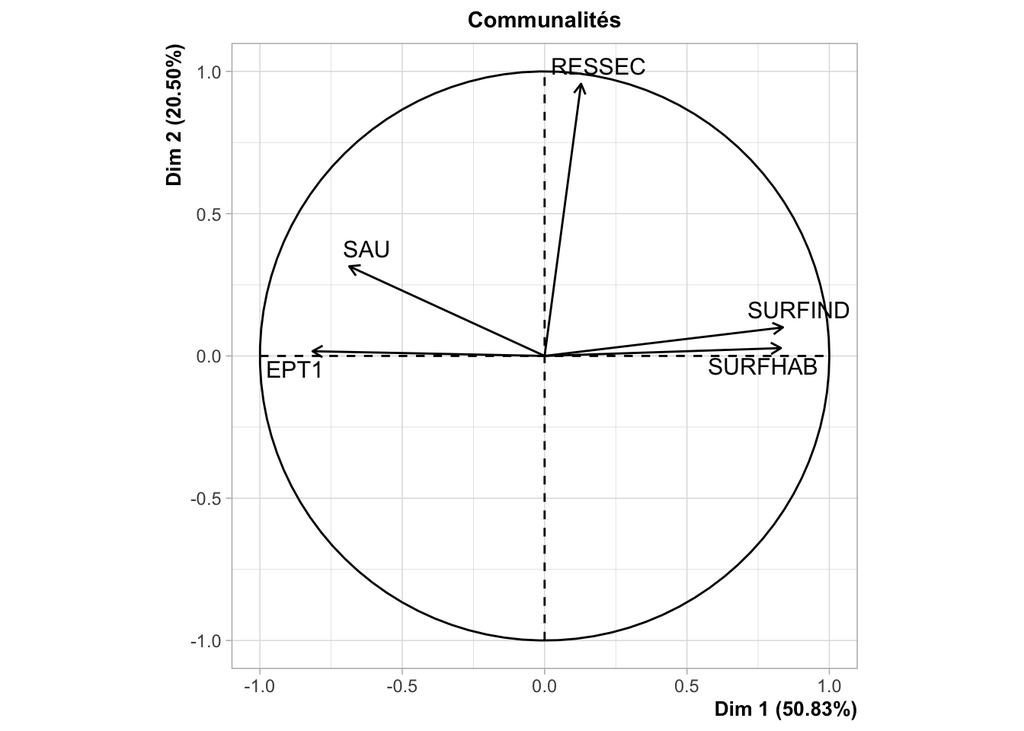

```r
plot.PCA(acp, axes=c(1,2), choix="var", title="Communalités")
```

Ou avec un peu de couleur pour indiquer la contribution de chaque variable:

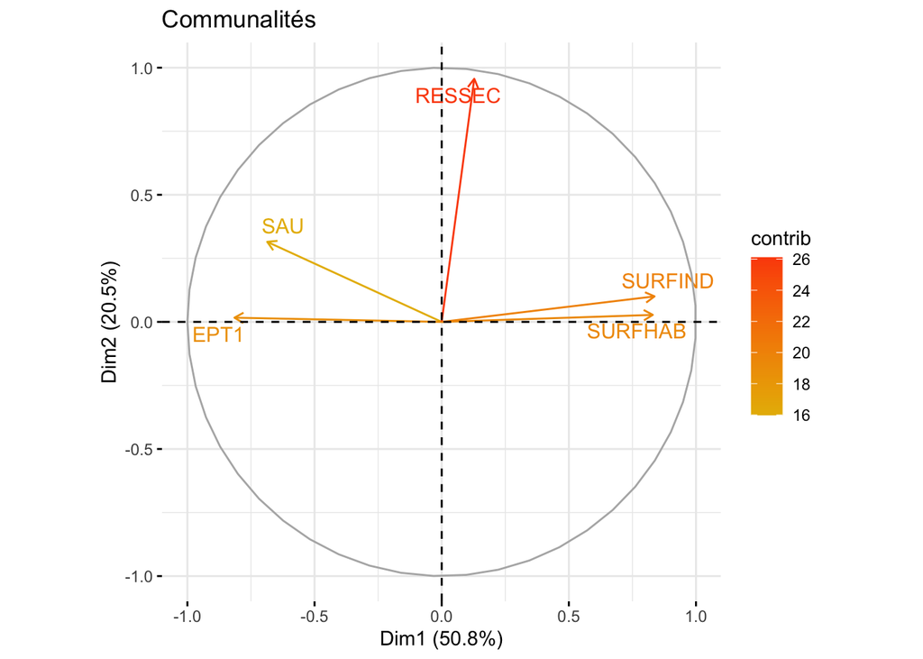

```r
fviz_pca_var(
    acp,
    col.var="contrib",
    gradient.cols=c("#E7B800", "#FC4E07"),
    repel=TRUE,    # Éviter la superposition de labels
    title="Communalités",
    axes=c(1,2)
)
```

Pour afficher les communalités brutes on va utiliser la fonction suivante: **N.B:** Dans le tableau on peut voir la corrélation entre les variables et les composantes, ce qui est important pour l’interprétation des différentes dimensions (interprétation est affiché dans l’autre notebook rmarkdown).

```r
acp$var$cor
```

```
##              Dim.1      Dim.2      Dim.3       Dim.4       Dim.5
## SAU     -0.6861891 0.31506870  0.6025246 -0.20686171 -0.15507600
## EPT1    -0.8150228 0.01652196  0.1536073  0.52467003  0.19128773
## SURFHAB  0.8302028 0.02769971  0.2409882  0.44599188 -0.23024308
## RESSEC   0.1281237 0.95643474 -0.2547142  0.05771148  0.02463733
## SURFIND  0.8370622 0.10049931  0.4434618 -0.10989165  0.28371160
```

C’est également intéressant et plus visuel de faire une graphique des contributions des différentes variables aux composantes:

Cette **première dimension** est fortement représentée par les variables de la proportion des surfaces industrielles (SURFIND), les surfaces d’habitation (SURFHAB) ainsi que par la proportion des emplois du secteur primaire (EPT1).

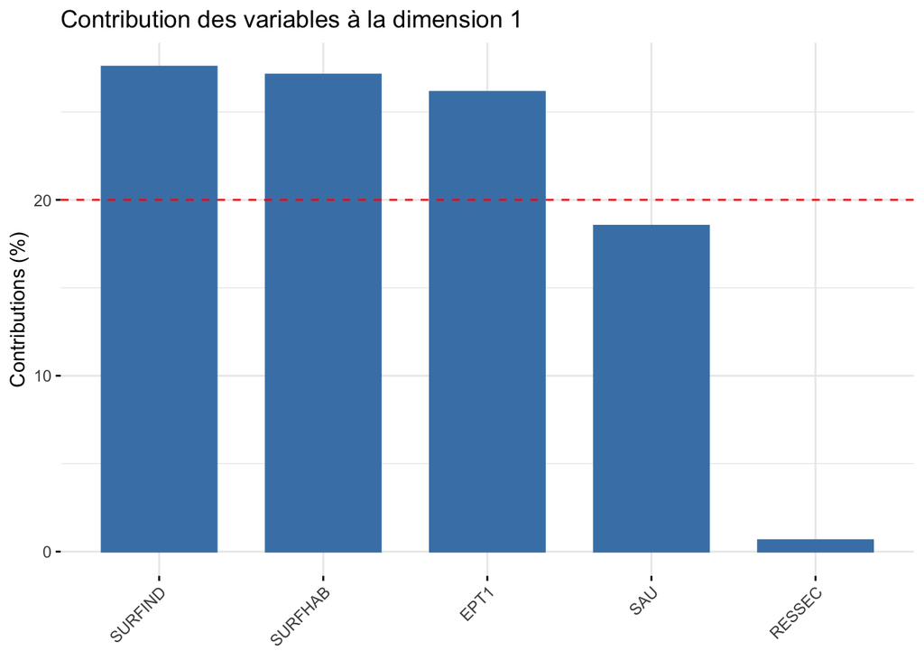

```r
fviz_contrib(acp,
             choice="var", axes=1, top=20,
             title="Contribution des variables à la dimension 1")
```

Cette **deuxième dimension** est fortement représentée par la variable de la proportion des maisons secondaires (RESSEC) parmi tout type de maisons.

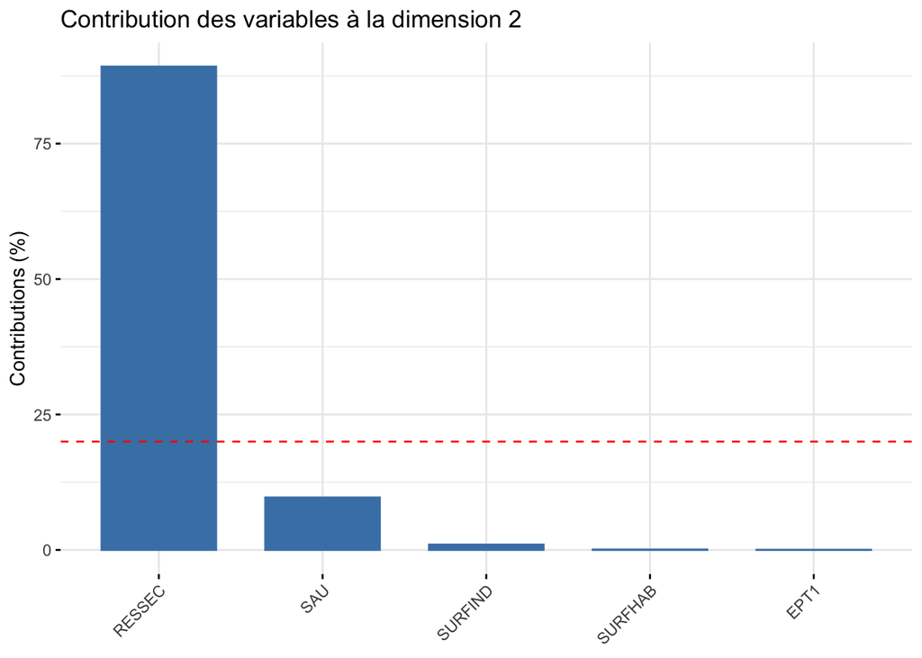

```r
fviz_contrib(acp,
             choice="var", axes=2, top=20,
             title="Contribution des variables à la dimension 2")
```

Cette **troixième dimension** est fortement représentée par la variable de la proportion des surfaces agricoles utiles (SAU).

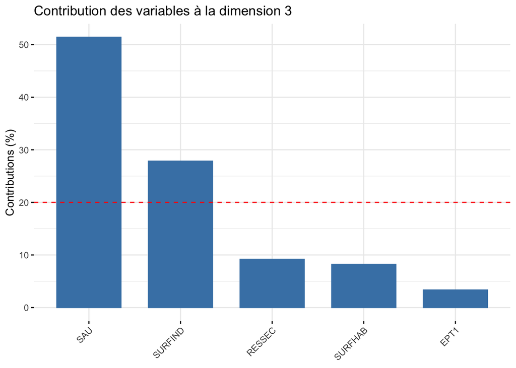

```r
fviz_contrib(acp,
             choice="var", axes=3, top=20,
             title="Contribution des variables à la dimension 3")
```

Cette **quatrième dimension** est fortement représentée par la variable de la proportion des emplois dans le secteur primaire (EPT1).

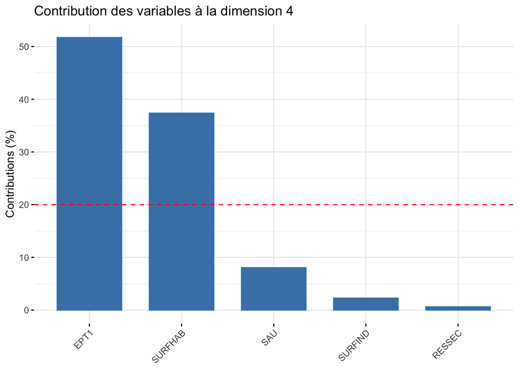

```r
fviz_contrib(acp,
             choice="var", axes=4, top=20,
             title="Contribution des variables à la dimension 4")
```

Finalement, la **cincquième dimension** est fortement représentée par la variable de la proportion des surfaces industrielles (SURFIND).

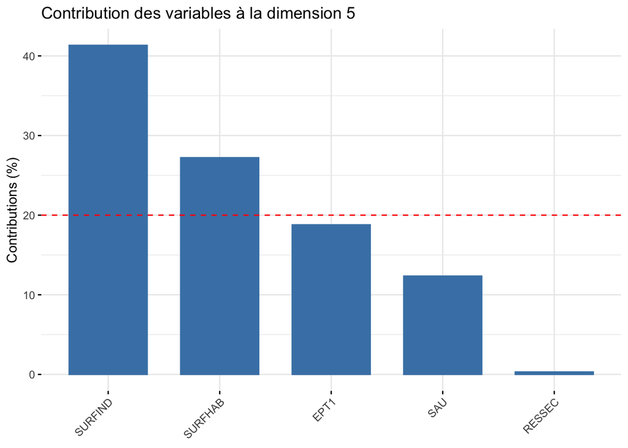

```r
fviz_contrib(acp,
             choice="var", axes=5, top=20,
             title="Contribution des variables à la dimension 5")
```

#### Représentation simultanée des variables et individus

Il est possible aussi de visualiser à la fois les variables et les régions (individus) dans le même graphique, sous forme d’un biplot:

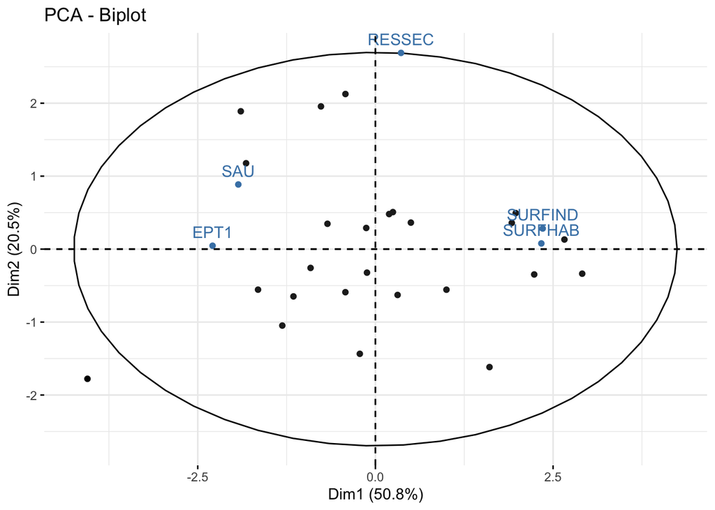

```r
fviz_pca_biplot(
    acp,
    geom.ind="point",
    geom.var=c("point", "text"),
    addEllipses=TRUE
)
```

### 4. Clustering

#### Introduction théorique

Le clustering est une méthode statistique qui **a comme but de grouper un ensemble d’individu ensemble de sorte que les individus dans le même groupe se ressemblent plus que les individus en dehors du groupe (Kaiser, 2022)**.

Parmi les méthodes de clustering les plus populaires, on trouve le k-means et la classification hiérarchique (CAH). **N.B:** Dans cette recherche, uniquememnt la CAH est appliqué pour génerer le clustering et la carte des clusters

#### La classification ascendante hiérarchique (CAH)

Cette méthode consiste à établir ce que l’on appelle une hiérarchie de groupe, c’est-à-dire que tous les individus sont d’abord isolés, puis les individus qui se ressemblent le plus sont réunis en groupes. C’est ainsi que se forme le dendrogramme. Le dendrogramme est un bon moyen de visualiser les données et leurs structures. Il facilite également la détermination du nombre idéal de classes.

La ACH nécessite deux choix importants:

Le premier est celui de la mesure de la distance. La distance la plus commune est la distance euclidienne (bien évidamment, d’autres sont possibles).

Le deuxième choix est celui du critère de lien, qui définit comment la distance entre deux clusters (ensemble d’individus) est calculée (par exemple la distance maximale, moyenne etc.).

**N.B:** Comme affiché ci-dessous, on utilise ici les memes données que dans l’étappe 2 (soit la génération de l’ACP), définis comme “d2”:

```r
# d2 = read.csv(file="../donnees/Etappe 2/acp_donnees_5.csv", sep="\t")
```

On séléctionne les variables qui sont inclues dans la CAH, soit la colonne 2 à 12 des données d2:

```r
d_sel = d2[, 2:12]
```

Dans R, le calcul de la CAH se fait en deux étapes. D’abord nous calculons la matrice des distances avec la fonction **dist()**:

```r
dist = dist(d_sel, method="euclidean")
```

Et par la suite la CAH en utilisant ici le critère de Ward qui est basé sur la différence de variance si les deux clusters sont réunis:

```r
clus_cah = hclust(dist(d_sel), method="ward.D2")
```

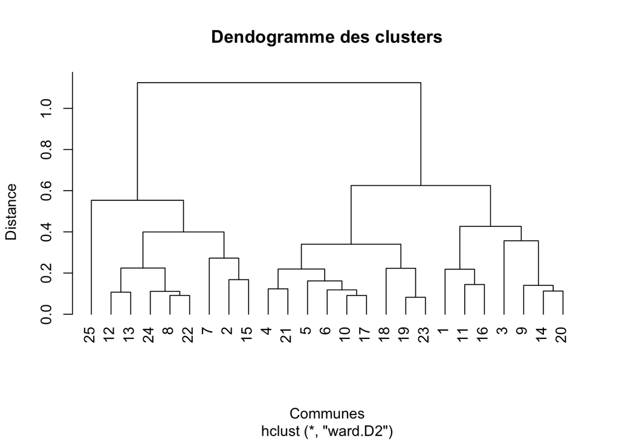

```r
plot(clus_cah, hang=-0.1, ylab="Distance", xlab="Communes", main="Dendogramme des clusters")
```

Pour obtenir un certain nombre de classes, nous pouvons couper ce dendrogramme horizontalement. L’idéal dans le présent cas semble être 4 groupes. Le partionnement (clustering) peut être obtenu ainsi:

```r
cah_partitions = cutree(clus_cah, 4)
cah_partitions
```

```
##  [1] 1 2 1 3 3 3 2 2 1 3 1 2 2 1 2 1 3 3 3 1 3 2 3 2 4
```

Pour analyser/interpréter plus tard les différents clusters dans le notebook_étude_territorial, j’effectue un boxplot pour les groupes/clusters:

```r
cl_1 = d_sel[c(1,3,9,11,14,16,20),]
cl_2 = d_sel[c(2,7,8,12,13,15,22,24),]
cl_3 = d_sel[c(4,5,6,10,17,18,19,21,23),]
cl_4 = d_sel[c(25),]
```

Boxplot des variables

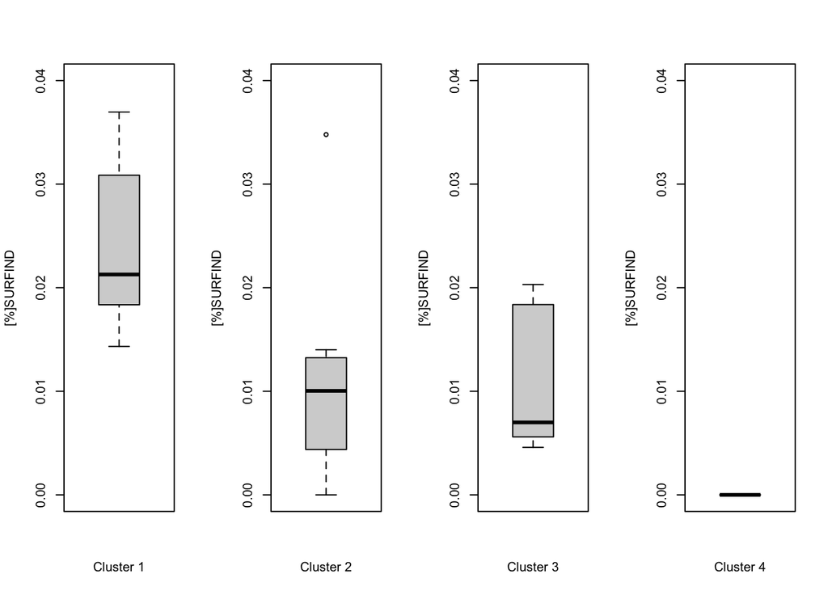

```r
#Comparaison SURFIND
par(mfrow=c(1,4))
boxplot(cl_1$SURFIND, ylim=c(0,0.04), xlab="Cluster 1", ylab="[%]SURFIND")
boxplot(cl_2$SURFIND, ylim=c(0,0.04), xlab="Cluster 2", ylab="[%]SURFIND")
boxplot(cl_3$SURFIND, ylim=c(0,0.04), xlab="Cluster 3", ylab="[%]SURFIND")
boxplot(cl_4$SURFIND, ylim=c(0,0.04), xlab="Cluster 4", ylab="[%]SURFIND")
```

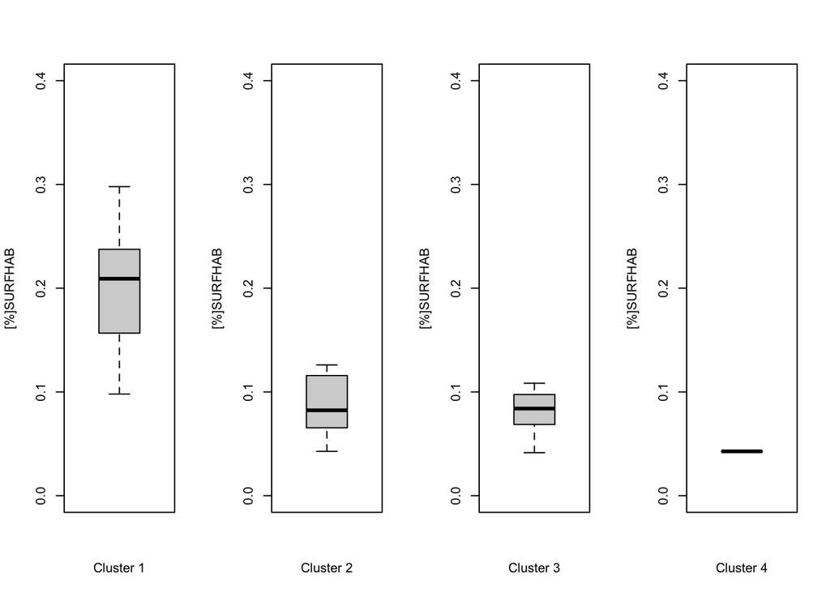

```r
#Comparaison SURFHAB
par(mfrow=c(1,4))
boxplot(cl_1$SURFHAB, ylim=c(0,0.4), xlab="Cluster 1", ylab="[%]SURFHAB")
boxplot(cl_2$SURFHAB, ylim=c(0,0.4), xlab="Cluster 2", ylab="[%]SURFHAB")
boxplot(cl_3$SURFHAB, ylim=c(0,0.4), xlab="Cluster 3", ylab="[%]SURFHAB")
boxplot(cl_4$SURFHAB, ylim=c(0,0.4), xlab="Cluster 4", ylab="[%]SURFHAB")
```

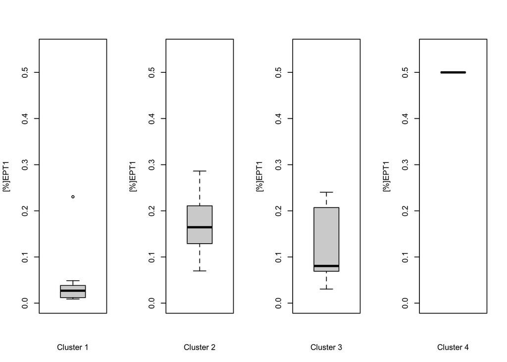

```r
#Comparaison EPT1
par(mfrow=c(1,4))
boxplot(cl_1$EPT1, ylim=c(0,0.55), xlab="Cluster 1", ylab="[%]EPT1")
boxplot(cl_2$EPT1, ylim=c(0,0.55), xlab="Cluster 2", ylab="[%]EPT1")
boxplot(cl_3$EPT1, ylim=c(0,0.55), xlab="Cluster 3", ylab="[%]EPT1")
boxplot(cl_4$EPT1, ylim=c(0,0.55), xlab="Cluster 4", ylab="[%]EPT1")
```

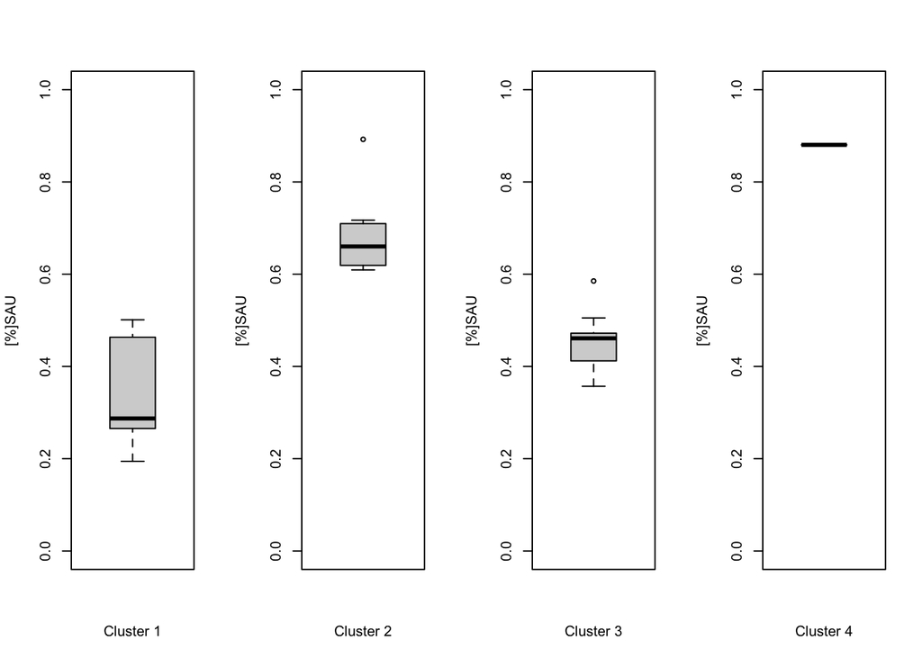

```r
#Comparaison SAU
par(mfrow=c(1,4))
boxplot(cl_1$SAU, ylim=c(0,1), xlab="Cluster 1", ylab="[%]SAU")
boxplot(cl_2$SAU, ylim=c(0,1), xlab="Cluster 2", ylab="[%]SAU")
boxplot(cl_3$SAU, ylim=c(0,1), xlab="Cluster 3", ylab="[%]SAU")
boxplot(cl_4$SAU, ylim=c(0,1), xlab="Cluster 4", ylab="[%]SAU")
```

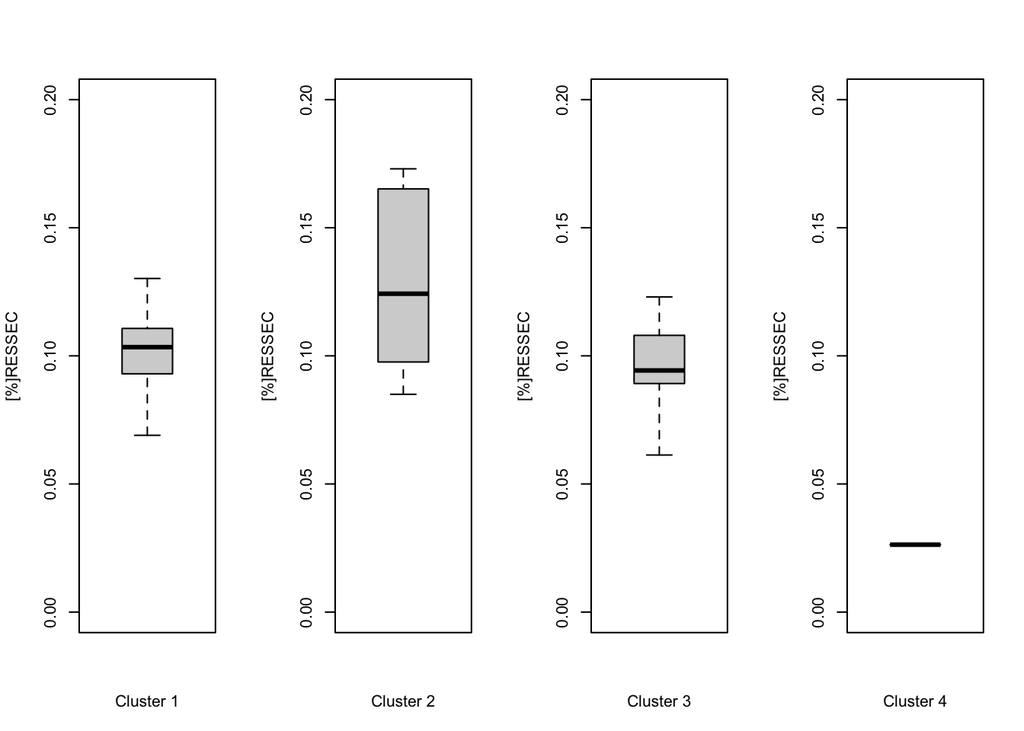

```r
#Comparaison SAU
par(mfrow=c(1,4))
boxplot(cl_1$RESSEC, ylim=c(0,0.2), xlab="Cluster 1", ylab="[%]RESSEC")
boxplot(cl_2$RESSEC, ylim=c(0,0.2), xlab="Cluster 2", ylab="[%]RESSEC")
boxplot(cl_3$RESSEC, ylim=c(0,0.2), xlab="Cluster 3", ylab="[%]RESSEC")
boxplot(cl_4$RESSEC, ylim=c(0,0.2), xlab="Cluster 4", ylab="[%]RESSEC")
```

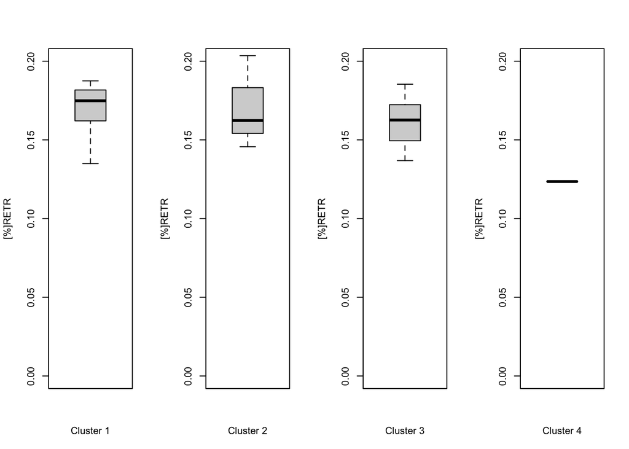

```r
#Comparaison RETR
par(mfrow=c(1,4))
boxplot(cl_1$RETR, ylim=c(0,0.2), xlab="Cluster 1", ylab="[%]RETR")
boxplot(cl_2$RETR, ylim=c(0,0.2), xlab="Cluster 2", ylab="[%]RETR")
boxplot(cl_3$RETR, ylim=c(0,0.2), xlab="Cluster 3", ylab="[%]RETR")
boxplot(cl_4$RETR, ylim=c(0,0.2), xlab="Cluster 4", ylab="[%]RETR")
```

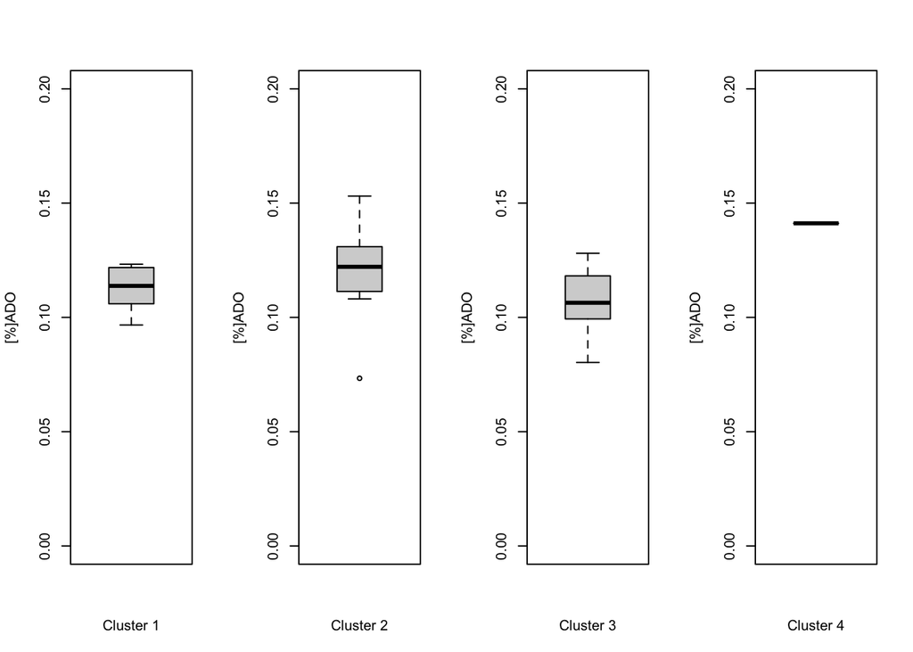

```r
#Comparaison ADO
par(mfrow=c(1,4))
boxplot(cl_1$ADO, ylim=c(0,0.2), xlab="Cluster 1", ylab="[%]ADO")
boxplot(cl_2$ADO, ylim=c(0,0.2), xlab="Cluster 2", ylab="[%]ADO")
boxplot(cl_3$ADO, ylim=c(0,0.2), xlab="Cluster 3", ylab="[%]ADO")
boxplot(cl_4$ADO, ylim=c(0,0.2), xlab="Cluster 4", ylab="[%]ADO")
```

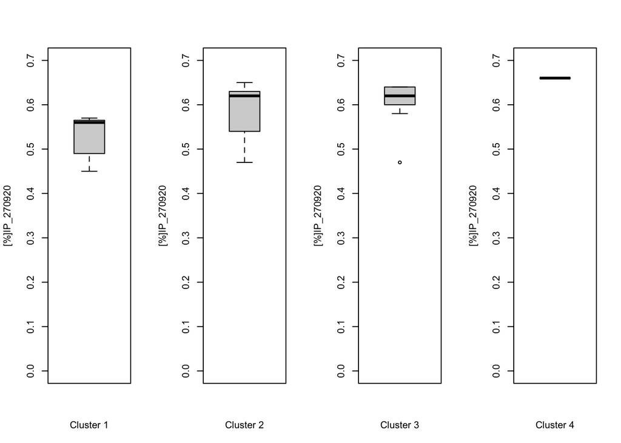

```r
#Comparaison IP_270920
par(mfrow=c(1,4))
boxplot(cl_1$IP_270920, ylim=c(0,0.7), xlab="Cluster 1", ylab="[%]IP_270920")
boxplot(cl_2$IP_270920, ylim=c(0,0.7), xlab="Cluster 2", ylab="[%]IP_270920")
boxplot(cl_3$IP_270920, ylim=c(0,0.7), xlab="Cluster 3", ylab="[%]IP_270920")
boxplot(cl_4$IP_270920, ylim=c(0,0.7), xlab="Cluster 4", ylab="[%]IP_270920")
```

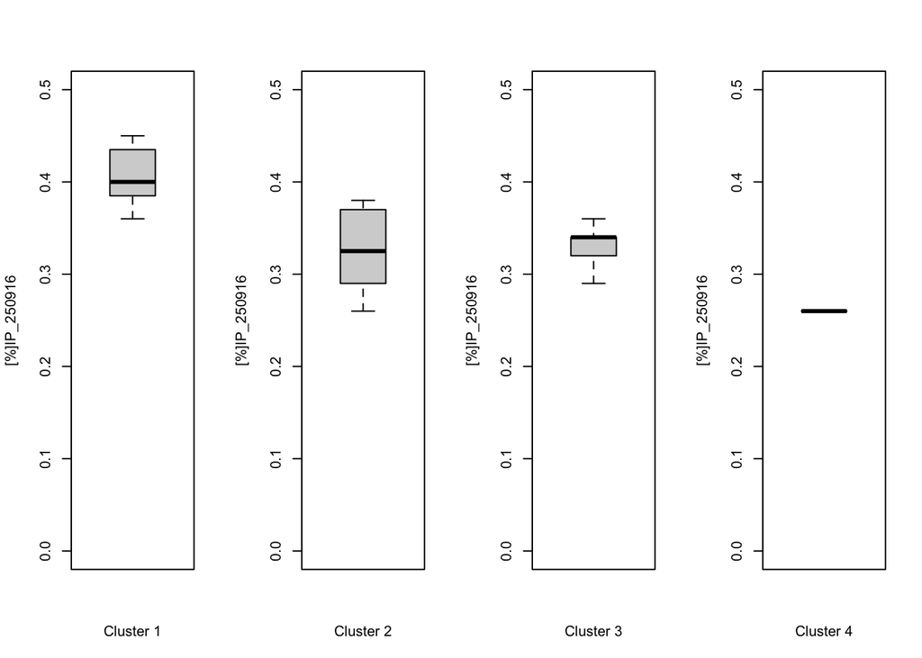

```r
#Comparaison IP_250916
par(mfrow=c(1,4))
boxplot(cl_1$IP_250916, ylim=c(0,0.5), xlab="Cluster 1", ylab="[%]IP_250916")
boxplot(cl_2$IP_250916, ylim=c(0,0.5), xlab="Cluster 2", ylab="[%]IP_250916")
boxplot(cl_3$IP_250916, ylim=c(0,0.5), xlab="Cluster 3", ylab="[%]IP_250916")
boxplot(cl_4$IP_250916, ylim=c(0,0.5), xlab="Cluster 4", ylab="[%]IP_250916")
```

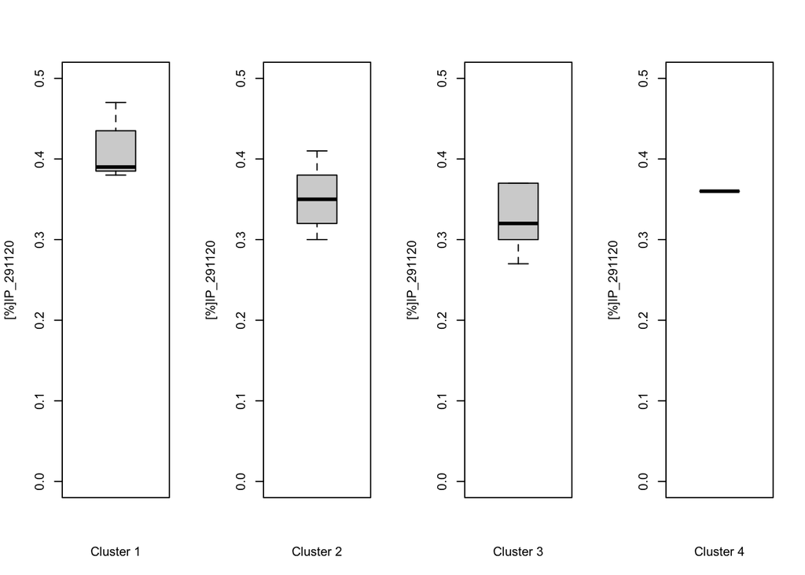

```r
#Comparaison IP_291120
par(mfrow=c(1,4))
boxplot(cl_1$IP_291120, ylim=c(0,0.5), xlab="Cluster 1", ylab="[%]IP_291120")
boxplot(cl_2$IP_291120, ylim=c(0,0.5), xlab="Cluster 2", ylab="[%]IP_291120")
boxplot(cl_3$IP_291120, ylim=c(0,0.5), xlab="Cluster 3", ylab="[%]IP_291120")
boxplot(cl_4$IP_291120, ylim=c(0,0.5), xlab="Cluster 4", ylab="[%]IP_291120")
```

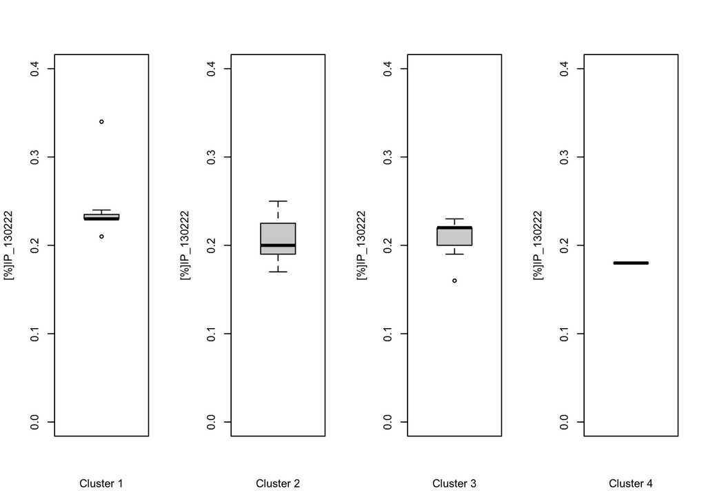

```r
#Comparaison IP_130222
par(mfrow=c(1,4))
boxplot(cl_1$IP_130222, ylim=c(0,0.4), xlab="Cluster 1", ylab="[%]IP_130222")
boxplot(cl_2$IP_130222, ylim=c(0,0.4), xlab="Cluster 2", ylab="[%]IP_130222")
boxplot(cl_3$IP_130222, ylim=c(0,0.4), xlab="Cluster 3", ylab="[%]IP_130222")
boxplot(cl_4$IP_130222, ylim=c(0,0.4), xlab="Cluster 4", ylab="[%]IP_130222")
```

Pour exporter ces données on utilise la fonction **write.csv()** (comme à la première étappe)

```r
write.csv(cah_partitions, file="clustering.csv")
```